# Predicting Survival Probability of NASA Aircraft Engines

Using Cox Proportional Hazards Model

Author

Jayme Reed & Brad Paton (Advisor: Dr. Cohen)

Published

April 29, 2025

Slides | Literature

## Introduction

As the COVID-19 pandemic demonstrated, the ability to predict the survival of a patient based on their symptoms and medical history is a major benefit as society deals with health crises such as pandemics. Those predictions would assist medical practitioners in triage and allow researchers the ability to generate predictions on the individuals who are at the greatest risk of losing their lives due to an illness. While the medical world is the most obvious use of survival predictions, the same methods can be applied to predicting bank failure, the survival probability of machines, machinery maintenance timelines, and insurance likelihood of payouts. There are various survival methods that can be examined, including the Cox proportional hazards model, which will be examined in this paper.

Cox proportional hazards (CPH) models are statistical regression models specializing in modeling time-to-event predictions with survival data. Survival data is data with a value for time and an event (Abeysekera and Sooriyarachchi 2009). For example, in a study investigating the survival likelihood of mechanical equipment, the time value would begin when the equipment begins functioning and would conclude in the event the equipment stops functioning (Tyler Smith and Margaret AK Ryan 2003). CPH models can use single or multiple covariates as a means of creating predictions until failure and are capable of dealing with survival data that contains censored data as well (S. W. Lee 2023). Censored data is when the information about an individual in a study is only known for a certain period of time, such as the length of the study (Klein and Moeschberger 2005). The models also have the advantage of being semi-parametric, which allows more flexibility as compared to other models (M.-C. Lee 2014).

As mentioned, CPH is used in various fields, primarily the health industry, but the usage of the model does not come without challenges. A COVID-19 study using data from a Pakistani hospital noted that the model was limited due to the recovery possibility of COVID-19 patients. CPH assumes as time goes on, the survival probability will approach zero with no survivors, which was not the case with COVID-19. Though CPH was not the best model for this study, the results of the model were that individuals who were asymptomatic and young had a higher chance of surviving the virus (Asghar, Khalil, and Uddin 2024). In 2024, a study was done in the US on the relationship between chest pain occurring and mortality of the person experiencing chest pain using CPH. A response to that study demonstrated the various limitations of CPH, with the primary concern being the constant hazards ratio assumption that CPH relies on. In the heart study, the effect of triglyceride-glucose was assumed to be a constant, but it is actually a value that fluctuates over time along with an individual’s body weight and blood glucose levels. As such, the model would struggle to predict correctly the effect of triglyceride-glucose given the violation of the constant hazards ratio (Jiang, Wu, and Li 2024).

An additional limitation of CPH comes from the data as the selection of covariates and the generation of the data can be biased. Two studies done using UK health data demonstrated how bias can impact the values for the covariates when relying on patient-submitted information. The first was a study on the connection between salt intake and the development of anxiety or depression after 14.5 years (Wang, Chang, and Lin 2025), and the second was a study on the association between postpartum depression and the development of two or more chronic diseases (Zhang, Cheng, and Carrillo-Larco 2025). Both of those studies relied on patient-submitted health data and survey responses supplemented with death records and other accessible health records. The reliance This created a possible bias in their data that may have negatively influenced their model as their collected data may not accurately reflect the true data. These articles provide examples of the care that needs to be taken when working with CPH models.

While health care is the dominant field in which CPH is used, a study in 2021 provides an example of using CPH in insurance fields. An insurance company in the Czech Republic provides policies for certain illness events, with the insured receiving money when the event occurs, which concludes the contract. To assist the company with predicting if an individual will have one of the illness events occur, a model using CPH was generated using gender, age, and region as the covariates (Zapletal 2021). A study in 2023 focused on the length of productive life of female Floridian goats to determine the factors that would impact the longevity of the goats. CPH was used to determine that both the age at first birth and the specific herd the female goat belonged to impacts the length of productive life (Ziadi et al. 2023). Both of these studies provide examples of CPH models outside the health industry.

While CPH can be applied across various fields for survival probability modeling, the method does have elements that may limit its accuracy that must be addressed. Two such elements are the constant hazards ratio and the censoring of data, as both can lead to limited accuracy. In addition, the necessity of a time-to-event value within the data source is something that needs to be considered when choosing to use CPH. Without that value, using CPH as a survival model will not be the appropriate method to take with that particular data. This value is also what makes CPH a prime modeling candidate with health data, as health metrics frequently have a time component to them. This is frequently seen when comparing someone over a period of time in a health study, as is done with medications and the development of cancer or other illnesses. However, while the usage of CPH is clear in the medical field, this paper will demonstrate using CPH within the field of mechanics and survival probability metrics of a machine.

## Methods

### Mathematical Formulas

There are two functions that are the backbone for CPH: the survival function and the hazard function. The survival function when $X$ is a continuous random variable is

$$S(x) = 1 - F(x) = 1 - Pr(X > x) = \int_x^\infty f(x) dx
\tag{1}$$

where $S(x)$ is the probability that an individual has survived past time $x$ (Klein and Moeschberger 2005).

The hazard function, which is also known as the hazard rate function, can be defined as

$$h(x) = \lim_{\Delta x \rightarrow 0} \frac{P[x\leq X < x + \Delta x | X \geq x]}{\Delta x}
\tag{2}$$

The function is used to describe how the chance of experiencing the event changes with time and only has the requirement of being non-negative (Klein and Moeschberger 2005).

CPH then uses both functions to develop its own model, specifically by adapting the hazard function. Since CPH is a proportional hazard model, the hazard function is adapted to deal with the relationship between time to event and the explanatory variables (Klein and Moeschberger 2005). It can be defined as

$$h(t|\mathbf{Z} ) = h_0(t)\text{exp}(\sum_{k=1}^p \beta_kZ_k)
\tag{3}$$

where,

- $h(t|\mathbf{Z})$ is the hazard rate at time $t$ for an subject with risk vector $\mathbf{Z}$
- $h_0(t)$ is a baseline hazard rate when all covariates are $0$
- $\text{exp}(\sum_{k=1}^p \beta_k Z_k)$ is a semi-parametric model
- $\beta_k$ is a parameter vector
- $Z_k$ is the risk vector (Klein and Moeschberger 2005)

CPH is considered a proportional hazards model due to the hazard ratio between two individuals being a constant value. The ratio of the hazard function for an individual with $\mathbf{Z}$ covariates where $Z_k = z+1$ and for an individual with $\mathbf{Z}^*$ covariates where $Z_k = z$ with all other predictors fixed (Nahhas 2025) is defined as

$$\frac{h(t|\mathbf{Z})}{h(t|\mathbf{Z}^*)} = \frac{h_0(t)\text{exp}[\sum_{k=1}^p \beta_k Z_k]}{h_0(t)\text{exp}[\sum_{k=1}^p \beta_k Z^*_k]} = \text{exp}[\sum_{k=1}^p \beta_k(Z_k - Z_k^*)]
\tag{4}$$
(Klein and Moeschberger 2005). The result of the hazard ratio (HR) is a constant that implies an association between a continuous predictor and the outcome. The interpretation of the HR is

- if HR $> 1$ implies a positive association such that $100\% \times (HR - 1)$ is the \% of greater risk for $Z = z+1$ when compared to $Z = z$.
- if HR $< 1$ implies a negative association such that $100\% \times (HR -1)$ is the \% of decreased risk for $Z = z+1$ when compared to $Z= z$.
- if HR $=1$ implies no association. (Nahhas 2025)

An additional useful equation is the cumulative hazard function. The cumulative hazard function can be defined as

$$\begin{align*}
H(x) = \int_0^x h(u) du
\end{align*}
\tag{5}$$

where $h(u)$ is the hazard rate function (Klein and Moeschberger 2005). This function provides a better understanding of the survival function for graphing purposes.

### Assumptions

There are four assumptions that a CPH model must meet in order to be an accurate model. For any violation of those assumptions, the data will need to be either transformed, stratified, or other covariates may need to be selected for the model. The four assumptions are the independence assumption, non-informative censoring, linearity assumption, and proportional hazards assumption.

**Independence Assumption**

CPH assumes that the survival times of observed subjects are independent of each other. This is similar to most regression models, though CPH does not assume that the residuals of the model are normally distributed or have constant variance (Nahhas 2025).

**Non-informative Censoring Assumption**

CPH assumes that censoring is non-informative, which means that each subject has the same risk of experiencing the event regardless of one of them being censored. Thus, the knowledge of censoring does not result in any new information being provided (Nahhas 2025).

**Linearity Assumption**

CPH assumes the relationship between covariates and the outcome is a linear relationship (Nahhas 2025). For CPH, the outcome for that relationship is the log of the hazard rate. This assumption is checked visually using the Martingale residuals for each covariate (Nahhas 2025). Martingale residuals are a type of residual used in survival analysis that shows the discrepancy between the observed and the expected number of events. The equation is
$$\begin{align*}
\text{Martingale Residuals} = \text{Observed Events} - \text{Expected Events}
\end{align*}$$

The resulting residuals are examined visually, and if they are linear and appear to have a slope of zero, the linearity assumption is not violated (Amini 2015). If a model is being generated with multiple covariates, multiple Martingale residual plots will need to be generated in order to verify this assumption for each covariate.

Below is an example plot showing Martingale residuals plotted for a covariate being tested. From the plot, it is visually clear that the residuals are linear and appear to have a slope of zero. For this covariate, the linearity assumption has not been violated.

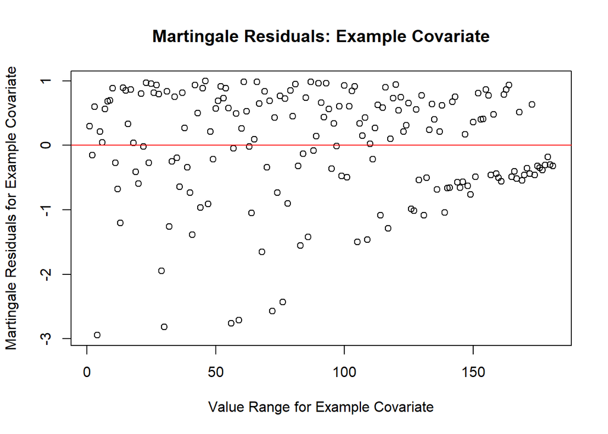

**Proportional Hazards Assumption**

The major assumption for CPH is the proportional hazards (PH) assumption, which states that the ratio of hazard rates for any two subjects must be constant at all times. This means the effect of the covariates must be constant over time (Bustan 2018). To test this assumption, the hypothesis test below is used:
$$\begin{align*}
H_0&: \text{the log hazard ratio for each covariate remains constant over time.} \\
H_1&: \text{the log hazard ratio for each covariate does not remain constant over time}
\end{align*}$$

To generate the p-value for the hypothesis test, the scaled Schoenfeld partial residuals are calculated for each covariate. The Schoenfeld partial residuals are the difference between the value of the covariate and the expected value of the covariate at the time of failure (Klein and Moeschberger 2005). If the global p-value is $< 0.05$, then the model has at least one covariate that violates the PH assumption, and each individual covariate p-value will need to be checked. If the global p-value is $> 0.05$, then the PH assumption holds for all covariates (Nahhas 2025). To visually confirm the PH assumption, the plot of the scaled Schoenfeld partial residuals for each covariate should be a horizontal line (Harrison and Pius 2021).

Violations of the PH assumption can be dealt with in several ways. If the covariate is categorical, one way is to stratify the covariate, which will generate a separate baseline hazard function for each level of the covariate (Harrison and Pius 2021). This removes the PH assumption for that covariate, though it will still be assumed for all other covariates in each level of the stratification (Nahhas 2025). If the covariate is continuous, one way is to add in a function of time based on the shape of the hazard ratio plot. This replaces the model’s time coefficient with a function of time as it assumes the covariate varies either linearly or non-linearly with time (Nahhas 2025).

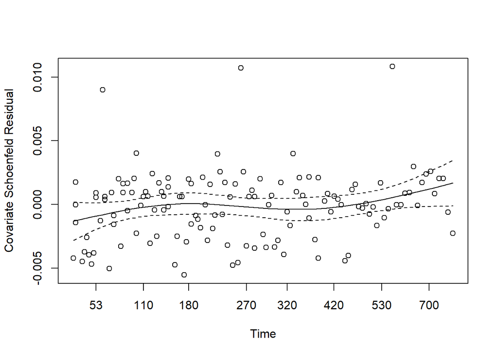

| variable | chisq | df | p |
| --- | --- | --- | --- |
| meal.cal | 4.0478025 | 1 | 0.0442289 |
| age | 0.4838469 | 1 | 0.4866850 |
| GLOBAL | 4.1100198 | 2 | 0.1280916 |

### Model Visualization

Two common model visualizations used for CPH are the forest plot and the Kaplan-Meier survival curve. The Kaplan-Meier curve assists in visualizing the initial survival model for the data, while the forest plot assists in visualizing the hazard ratio after generating a model.

**Kaplan Meier Survival Curve**

The Kaplan-Meier (KM) estimator is also known as the Product-Limit estimator and was proposed by Kaplan and Meier in 1958. The estimator can be defined as

$$\hat{S}(t) = \begin{cases}
1 \qquad \qquad \qquad \: \text{if } \; t< t_1,\\
\prod_{t_\leq t}[1 - \frac{d_j}{Y_i}], \quad\text{if} \; t_1 \leq t
\end{cases}
\tag{6}$$
where,

- $d_i$ is the number of events at time $t_i$
- $Y_i$ is the number of individuals who are risk at time $t_i$ (Klein and Moeschberger 2005)

KM is a non-parametric estimate, which means it makes no assumption of the shape of the base survival function (Nahhas 2025) and is considered to be well defined up until the largest observed study time, $t_{max}$ (Klein and Moeschberger 2005). The survival curve provides a visualization of the KM estimator and is important when modeling survival data because it demonstrates the time when the event being modeled is expected to occur.

Below is an example survival curve showing survival probabilities over time. The line represents the median survival probability, with the red area around it showing the 95% confidence interval for the values. The curve can be interpreted as showing the probability of an event that would be expected to happen around a time of 300, where the survival probability is below 50% (Kuitunen 2021).

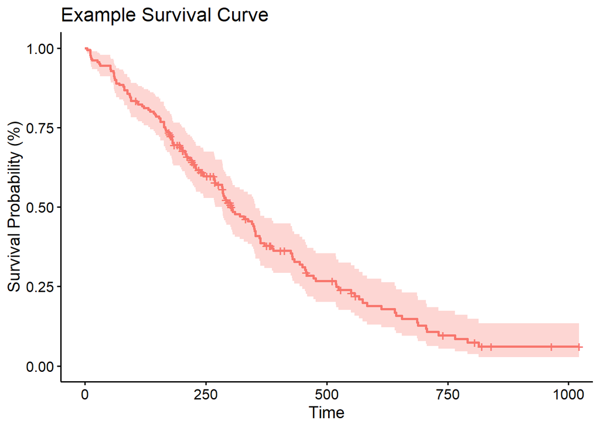

**Forest Plots**

Forest plots can be used to visualize the effects each covariate in the model has on the hazard ratio. The resulting plot contains each covariate on the y-axis, with the estimated effect on the hazard ratio on the the x-axis. The plot contains whiskers demonstrating a 95% confidence interval for the effect. A positive effect indicates a positive correlation with the hazard ratio, where the higher the number is, the more severe the effect on the hazard ratio.

An example forest plot is shown below, plotting the hazard ratio for each covariate in the model. The point represents the calculated hazard ratio, and the whiskers show the 95% confidence interval.

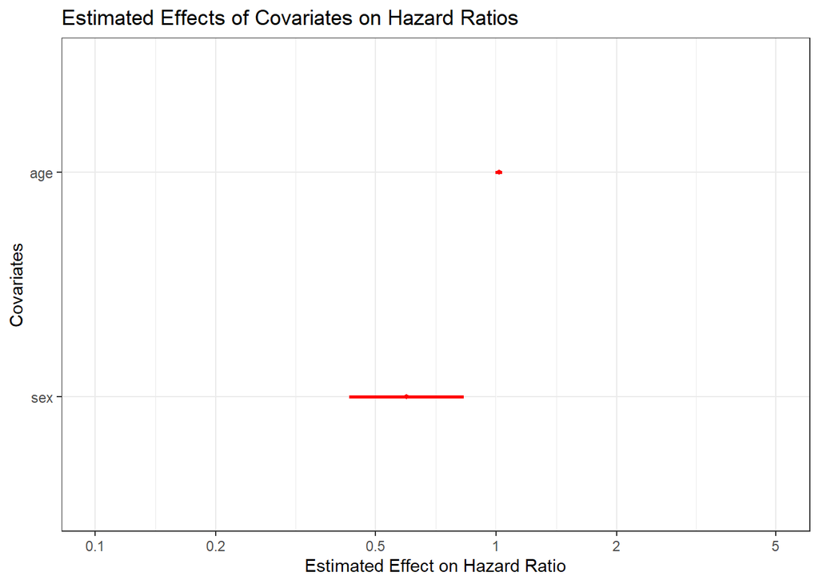

### Evaluation

Evaluation of the accuracy of the CPH model is done using the concordance index, which is used to measure the amount of agreement between two variables. Specifically, the value looks at concordant pairs and discordant pairs. A concordant pair is when either $x_i < x_j$ and $y_i < y_j$ or $x_i > x_j$ and $y_i > y_j$. A discordant pair is when either $x_i$ or $y_i$ are not in the same place, such as $x_i < x_j$ but $y_j < y_i$ (Therneau and Watson 2017). In terms of survival, this can be thought of as examining when the failure event occurs. If two subjects, A and B, are compared, with subject A having a higher risk, the pair would be considered concordant if subject A does have the failure event occur before subject B.

The equation for concordance with CPH is

$$C =\frac{c + \frac{t_x}{2}}{c + d + t_x}
\tag{7}$$

where,

- $c$ is the count of pairs that are concordant
- $d$ is the count of pairs that are discordant
- $t_x$ are the pairs tied to the predictor $x$ (Therneau and Watson 2017)

The concordance index will produce a value between 0 and 1. A value of 1 means all pairs are correctly ordered, and a value of 0 means none of the pairs are correctly ordered. Any values between 0 and 1 indicate how accurate the CPH model is with the data (Therneau and Watson 2017).

### Survival Probability

CPH can be used to predict the survival probability at a specific time $S(t|X=x)$, and the hazard ratio for an individual when compared to a reference individual $\frac{h(t|X=x)}{h(t|X=x_{ref}}$ (Nahhas 2025). The equation is

$$S(t) = e^{-H(t)}
\tag{8}$$

where, $H(t)$ is the cumulative hazard up to time $t$.

If the resulting probability is greater than or equal to 50%, it is assumed the event has not occurred. If the resulting probability is less than 50%, it is assumed the event has occurred. It is also possible to generate a plot of the estimated survival curves for all values of $t$ that are desired. However, CPH is not able to predict the specific time the event is going to occur, which is considered a limitation of the model.

## Analysis and Results

### Data Structure, Exploration, and Visualization

Though CPH is typically used with health data, it does have applications in other fields. This paper will study the survival probability of a NASA aircraft engine using data provided by NASA for the study on propagation modeling (Saxena et al. 2008). In particular, this paper will be examining the data from the engine design two, which has a training dataset and a testing dataset.

**Data Structure**

Each engine in the NASA data has an unknown amount of wear, manufacturing variation, and sensor noise, which will impact the survival time. In the training dataset, each engine is operating normally at the beginning of the time series, will develop a fault, and experience failure at some point. All engines will have failed in the training dataset. The conditions the engines are subjected to are represented by three operational setting fields and twenty-one sensor measurement fields. In the testing dataset, none of the engines have experienced failure (Saxena et al. 2008).

A column indicating status is needed for both the training and testing datasets. The value 0 will be used to indicate if the machine is still working and the value 1 will be used for the last cycle before the engine fails. Both values will appear in the training dataset as all engines in that dataset will eventually fail. The testing dataset will only have the value of 0, as none of the machines have failed in that dataset.

The table below shows the structure for the combined training and testing data after the transformations described above.

```r
testurl <- 'https://raw.githubusercontent.com/JR-87/capstone4ds_reed/refs/heads/main/test_FD002.txt'

test <- read.delim(testurl, header = TRUE, sep = '') %>%
  mutate(status = 0,
         id = id + 260)

trainurl <- 'https://raw.githubusercontent.com/JR-87/capstone4ds_reed/refs/heads/main/train_FD002.txt'

train <- read.delim(trainurl, header = TRUE, sep = '') %>%
  group_by(id) %>%
  mutate(status = if_else(row_number() == n(), 1, 0)) %>%
  ungroup()

data_all <- rbind(train, test)


kable(head(data_all, n = 5), format = "markdown", caption = 'NASA Aircraft Engine Data')
```

NASA Aircraft Engine Data

| id | time | os1 | os2 | os3 | sm1 | sm2 | sm3 | sm4 | sm5 | sm6 | sm7 | sm8 | sm9 | sm10 | sm11 | sm12 | sm13 | sm14 | sm15 | sm16 | sm17 | sm18 | sm19 | sm20 | sm21 | status |
| --- | --- | --- | --- | --- | --- | --- | --- | --- | --- | --- | --- | --- | --- | --- | --- | --- | --- | --- | --- | --- | --- | --- | --- | --- | --- | --- |
| 1 | 1 | 34.9983 | 0.8400 | 100 | 449.44 | 555.32 | 1358.61 | 1137.23 | 5.48 | 8.00 | 194.64 | 2222.65 | 8341.91 | 1.02 | 42.02 | 183.06 | 2387.72 | 8048.56 | 9.3461 | 0.02 | 334 | 2223 | 100.00 | 14.73 | 8.8071 | 0 |
| 1 | 2 | 41.9982 | 0.8408 | 100 | 445.00 | 549.90 | 1353.22 | 1125.78 | 3.91 | 5.71 | 138.51 | 2211.57 | 8303.96 | 1.02 | 42.20 | 130.42 | 2387.66 | 8072.30 | 9.3774 | 0.02 | 330 | 2212 | 100.00 | 10.41 | 6.2665 | 0 |
| 1 | 3 | 24.9988 | 0.6218 | 60 | 462.54 | 537.31 | 1256.76 | 1047.45 | 7.05 | 9.02 | 175.71 | 1915.11 | 8001.42 | 0.94 | 36.69 | 164.22 | 2028.03 | 7864.87 | 10.8941 | 0.02 | 309 | 1915 | 84.93 | 14.08 | 8.6723 | 0 |
| 1 | 4 | 42.0077 | 0.8416 | 100 | 445.00 | 549.51 | 1354.03 | 1126.38 | 3.91 | 5.71 | 138.46 | 2211.58 | 8303.96 | 1.02 | 41.96 | 130.72 | 2387.61 | 8068.66 | 9.3528 | 0.02 | 329 | 2212 | 100.00 | 10.59 | 6.4701 | 0 |
| 1 | 5 | 25.0005 | 0.6203 | 60 | 462.54 | 537.07 | 1257.71 | 1047.93 | 7.05 | 9.03 | 175.05 | 1915.10 | 7993.23 | 0.94 | 36.89 | 164.31 | 2028.00 | 7861.23 | 10.8963 | 0.02 | 309 | 1915 | 84.93 | 14.13 | 8.5286 | 0 |

**Data Visualization**

```r
train_grouped <- train %>%
  group_by(id) %>%
  slice_max(time)

data_grouped <- data_all %>%
  group_by(id) %>%
  slice_max(time)


summarymetrics <- data.frame(c("Minimum", "Median", "Mean", "Standard Deviation", "Maximum"),
                             c(min(train_grouped$time),
                               median(train_grouped$time),
                               mean(train_grouped$time),
                               sd(train_grouped$time),
                               max(train_grouped$time)))

colnames(summarymetrics) <- c("Metric", "Value")
summarymetrics$Value <- round(summarymetrics$Value, digits = 2)
kable(summarymetrics, format = "markdown", align = "c")
```

| Metric | Value |
| --- | --- |
| Minimum | 128.00 |
| Median | 199.00 |
| Mean | 206.77 |
| Standard Deviation | 46.78 |
| Maximum | 378.00 |

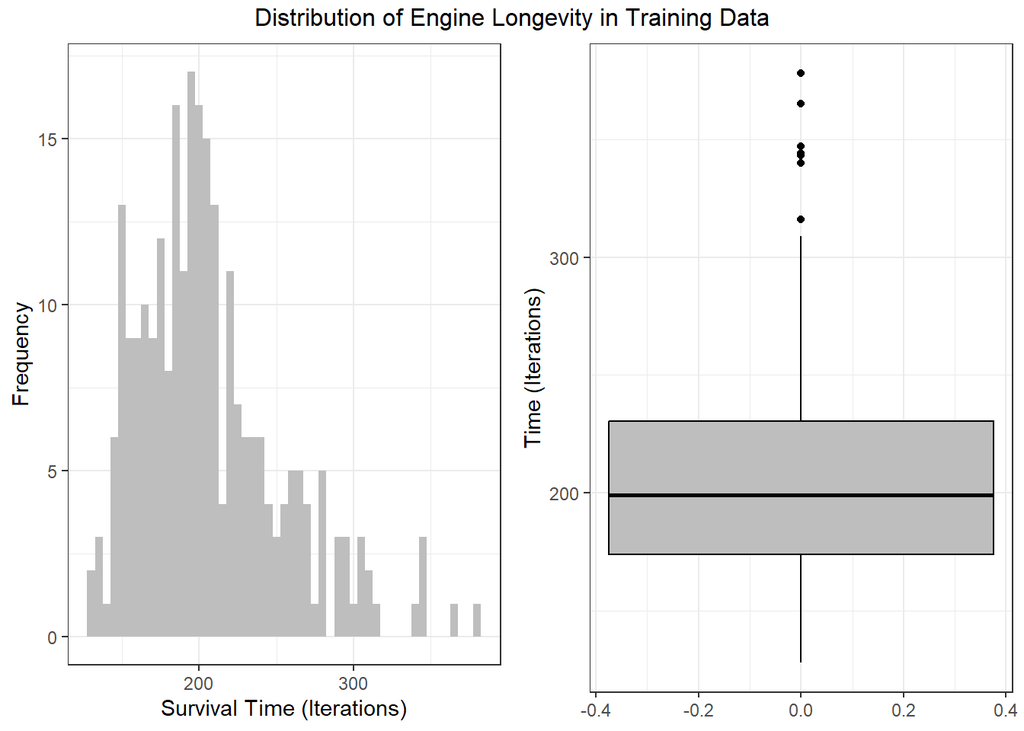

To determine the initial survival function, using the training data, the Kaplan-Meier survival curve was generated and is shown below. The graph visualizes the survival curve and the information that was gathered through the histogram.

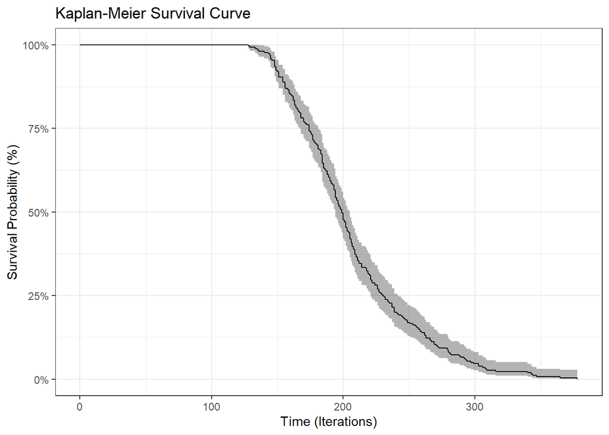

```r
t <- as.matrix(train_grouped[, "time"])
s <- as.matrix(train_grouped[, "status"])

km_fit <- survfit(Surv(t, s) ~ 1)

autoplot(km_fit) + theme_bw() + labs(y = "Survival Probability (%)", x = 'Time (Iterations)', title = "Kaplan-Meier Survival Curve")
```

### Creating Cox Proportional Hazards Model

**Generating Models**

Generation of the CPH models will be done using R, specifically the R package `survival`. To generate the CPH model with properly formatted survival data, a survival object is created by running `Surv(time, event)`, where `time` is the time field and `event` is the event field. To generate the actual model, the survival object is then applied to the function `coxph(survival object ~ x, data)`, where `x` represents the covariate(s) and `data` is the survival data that is being modeled (R Core Team 2019).

Based on the information provided by NASA on their data, there are various sensors and operational setting fields that do not impact the survival rate of an engine. To determine which covariates are statistically significant, the below univariate test was run. The test uses the Wald test to determine which covariates will significantly impact the model individually. The covariates in which the p-value is $< 0.05$ will be considered statistically significant. The table displays the covariate, the $\beta$ value, the hazard ratio (HR), the 95% confidence interval for the hazard ratio, and the p-value generated from the Wald test. As can be seen, none of the covariates are statistically signification on their own.

```r
surv_object <- Surv(data_grouped$time, data_grouped$status)

covariates <- c("os1", "os2", "os3", "sm1", "sm2", "sm3", "sm4", "sm5", "sm6", "sm7",
                "sm8", "sm9", "sm10", "sm11", "sm12", "sm13", "sm14", "sm15", "sm16",
                "sm17", "sm18", "sm19", "sm20", "sm21")


forms <- sapply(covariates,
                        function(x) as.formula(paste('Surv(time, status)~', x)))

univ_models <- lapply(forms, function(x){coxph(x, data = data_grouped)})

# Extract data
univ_results <- lapply(univ_models,
                       function(x){
                          x <- summary(x)
                          p.value<-signif(x$wald["pvalue"], digits=2)
                          beta<-signif(x$coef[1], digits=2);#coefficient beta
                          HR <-signif(x$coef[2], digits=2);#exp(beta)
                          HR.confint.lower <- signif(x$conf.int[,"lower .95"], 2)
                          HR.confint.upper <- signif(x$conf.int[,"upper .95"],2)
                          CI <- paste0("(", HR.confint.lower, "-", HR.confint.upper, ")")
                          res<-c(beta, HR, CI, p.value)
                          names(res)<-c("beta", "HR", "95% CI",
                                        "p-value")
                          return(res)
                         })
kable(as.data.frame(univ_results))
```

|  | os1 | os2 | os3 | sm1 | sm2 | sm3 | sm4 | sm5 | sm6 | sm7 | sm8 | sm9 | sm10 | sm11 | sm12 | sm13 | sm14 | sm15 | sm16 | sm17 | sm18 | sm19 | sm20 | sm21 |
| --- | --- | --- | --- | --- | --- | --- | --- | --- | --- | --- | --- | --- | --- | --- | --- | --- | --- | --- | --- | --- | --- | --- | --- | --- |
| beta | 0.00064 | -0.029 | 0.0025 | -5e-04 | -0.00013 | 0.00015 | 0.00023 | -0.0039 | -0.0023 | -7e-05 | 9.9e-05 | -9.6e-05 | 0.18 | 0.015 | -7.4e-05 | 0.00027 | -0.0011 | -0.011 | 6.2 | 0.00048 | 1e-04 | 0.0067 | -0.0013 | -0.0021 |
| HR | 1 | 0.97 | 1 | 1 | 1 | 1 | 1 | 1 | 1 | 1 | 1 | 1 | 1.2 | 1 | 1 | 1 | 1 | 0.99 | 500 | 1 | 1 | 1 | 1 | 1 |
| 95% CI | (0.99-1) | (0.67-1.4) | (0.99-1) | (1-1) | (1-1) | (1-1) | (1-1) | (0.97-1) | (0.98-1) | (1-1) | (1-1) | (1-1) | (0.44-3.2) | (0.97-1.1) | (1-1) | (1-1) | (1-1) | (0.81-1.2) | (4.7e-09-5.3e+13) | (1-1) | (1-1) | (0.97-1) | (0.99-1) | (0.98-1) |
| p-value | 0.87 | 0.88 | 0.69 | 0.83 | 0.94 | 0.82 | 0.67 | 0.81 | 0.83 | 0.86 | 0.86 | 0.64 | 0.73 | 0.51 | 0.87 | 0.7 | 0.15 | 0.92 | 0.63 | 0.84 | 0.85 | 0.69 | 0.83 | 0.83 |

To determine the best model to use for this analysis, a forward and backward stepwise regression was done to generate the models with the best Akaike Information Criterion (AIC) and Bayesian Information Criterion (BIC) values. The second and third models were generated using this regression method. The fourth model was generated using the Lasso penalized Cox regression method.

The table below provides the model number, the covariates used, the AIC and BIC from the stepwise regression if applicable, and the concordance index.

```r
all_cov <- coxph(data = data_grouped, surv_object ~ os1 + os2 + os3 + sm1 + sm2 + sm3 + sm4 + sm5 + sm6 + sm7 + sm8 + sm9 + sm10 + sm11 + sm12 + sm13 + sm14 + sm15 + sm16 + sm17 + sm18 + sm19 + sm20 + sm21)

#stepwise regression models
aic <- MASS::stepAIC(all_cov, trace = 0)
n <- nrow(data_grouped)
bic <- step(all_cov, direction = "both", k = log(n), trace = 0)

#input/out for glmnet
all_mod <- model.matrix(Surv(time, status) ~  + os2 + os3 + sm1 + sm2 + sm3 + sm4 + sm5 + sm6 + sm7 + sm8 + sm9 + sm10 + sm11 + sm12 + sm13 + sm14 + sm15 + sm16 + sm17 + sm18 + sm19 + sm20 + sm21, data = data_grouped)[, -1]

# lasso penalized cox
cvfit <- cv.glmnet(all_mod, surv_object, family = "cox")
coefs <- coef(cvfit, s = "lambda.min")
new_cov <- rownames(coefs)[which(coefs != 0)]

#all Cox models
#all covariates
cox1 <- coxph(data = data_grouped, surv_object ~ os1 + os2 + os3 + sm1 + sm2 + sm3 + sm4 + sm5 + sm6 + sm7 + sm8 + sm9 + sm10 + sm11 + sm12 + sm13 + sm14 + sm15 + sm16 + sm17 + sm18 + sm19 + sm20 + sm21)

#aic
cox2 <- coxph(data = data_grouped, surv_object ~ os3 + sm3 + sm4 + sm5 + sm8 + sm9 + sm15 + sm16 + sm17 + sm18 + sm20)

#bic
cox3 <- coxph(data = data_grouped, surv_object ~ os3 + sm3 + sm4 + sm8 + sm9 + sm15 + sm18)

#lasso
cox4 <- coxph(data = data_grouped, surv_object ~ os2 + sm1 + sm3 + sm4 + sm9 + sm10 + sm11 + sm14 + sm15 + sm16 + sm17 + sm18)
```

| Model | Covariates | AIC | BIC | Concordance |
| --- | --- | --- | --- | --- |
| model 1 | All covariates | 2449.92 | 2547.71 | 0.6956658 |
| model 2 | os3, sm3, sm4, sm5, sm8, sm9, sm15, sm16, sm17, sm18, sm20 | 2431.88 | N/A | 0.6917216 |
| model 3 | os3, sm3, sm4, sm8, sm9, sm15, sm18 | N/A | 2461.31 | 0.6833401 |
| model 4 | os2, sm1, sm3, sm4, sm9, sm10, sm11, sm14, sm15, sm16, sm17, sm18 | N/A | N/A | 0.6788580 |

All four models were checked for the CPH assumptions. All but the first model failed the assumptions, even after adapting the covariate using stratification and/or removal. As such, the first model was the one selected for the continuing analyses.

While model one does have initially contain all 24 covariates, there are two that will need to be removed before proceeding with the analysis due to infinite coefficients and linearly dependence. The covariate sm19 is linearly dependent on another value, and the covariate sm16 resulted in a possible infinite coefficient. The following analysis will be done using model one without sm16 and sm19. The below tables provide the summary values from the model.

```r
cox1.1 <- coxph(data = data_grouped, surv_object ~ os1 + os2 + os3 + sm1 + sm2 + sm3 + sm4 + sm5 + sm6 + sm7 + sm8 + sm9 + sm10 + sm11 + sm12 + sm13 + sm14 + sm15 + sm17 + sm18 + sm20 + sm21)

ci <- cox1.1$concordance[6]
```

| term | estimate | std.error | statistic | p.value |
| --- | --- | --- | --- | --- |
| os1 | -3.9742724 | 10.0659086 | -0.3948250 | 0.6929720 |
| os2 | 26.0627144 | 100.9137964 | 0.2582671 | 0.7962008 |
| os3 | 121.3783096 | 250.4716879 | 0.4845989 | 0.6279609 |
| sm1 | 30.4694993 | 71.7370082 | 0.4247389 | 0.6710270 |
| sm2 | 0.0605400 | 0.2301072 | 0.2630946 | 0.7924776 |
| sm3 | 0.0444578 | 0.0163241 | 2.7234447 | 0.0064605 |
| sm4 | 0.0431476 | 0.0157465 | 2.7401397 | 0.0061413 |
| sm5 | 48.6182429 | 65.8324209 | 0.7385152 | 0.4602014 |
| sm6 | -39.9302995 | 36.4746967 | -1.0947397 | 0.2736307 |
| sm7 | -0.0993847 | 0.1608341 | -0.6179331 | 0.5366195 |
| sm8 | 2.2569004 | 1.6442593 | 1.3725939 | 0.1698786 |
| sm9 | -0.0306124 | 0.0117657 | -2.6018326 | 0.0092727 |
| sm10 | 15.2195207 | 28.7519029 | 0.5293396 | 0.5965699 |
| sm11 | 0.4295235 | 0.5638953 | 0.7617079 | 0.4462343 |
| sm12 | 0.0129785 | 0.2060872 | 0.0629759 | 0.9497857 |
| sm13 | -1.3811545 | 1.5655456 | -0.8822192 | 0.3776583 |
| sm14 | 0.0150787 | 0.0127196 | 1.1854688 | 0.2358322 |
| sm15 | 8.7483795 | 3.5100698 | 2.4923662 | 0.0126895 |
| sm17 | 0.1061484 | 0.0705347 | 1.5049114 | 0.1323469 |
| sm18 | -14.8583117 | 29.4519676 | -0.5044930 | 0.6139150 |
| sm20 | -1.0226085 | 0.6695146 | -1.5273878 | 0.1266646 |
| sm21 | -0.3429034 | 1.2399794 | -0.2765396 | 0.7821336 |

| n | nevent | concordance | std.error.concordance | logLik | statistic.log | p.value.log | statistic.wald | p.value.wald | statistic.sc | p.value.sc |
| --- | --- | --- | --- | --- | --- | --- | --- | --- | --- | --- |
| 519 | 260 | 0.6955986 | 0.0181589 | -1202.136 | 106.0594 | 0 | 80.32 | 0 | 86.02511 | 0 |

The forest plot for model one is shown below. The covariates that are closest to the value of one have a hazard rate that has less effect on the calculated hazard ratio for the entire model.

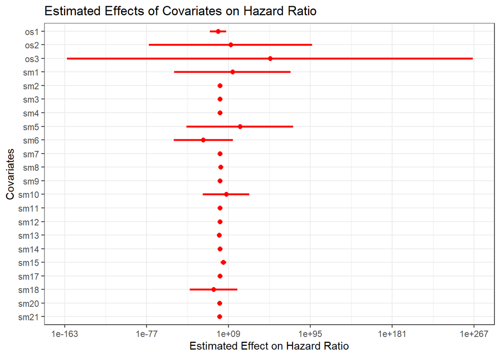

### Checking Assumptions

After determining the model to use with the covariates, the CPH assumptions need to be tested to confirm the model is a valid CPH model. The model may have a high concordance index, but it may not be valid for CPH to use to predict the survival probability. If any of the assumptions for the model are not met, the model will need to be modified.

**Independence Assumption**

The survival times for each individual engine in the data are independent of each other. The failure of one engine does not impact the failure of another, so this assumption is met.

**Non-informative Censoring Assumption**

While the data that was pulled from the training set does not include censored data, all of the data from the testing dataset is censored, as those engines had not experienced failure in the study time period. However, it is known that those engines will experience failure at some point, and knowing those engines are censored does not provide any new information. As such, this assumption is met.

**Linearity Assumption**

To check the linearity assumption, the residuals of the model are needed, which can be generated using the `resid` function in R and assigning the type to be martingale (`resid(type = "martingale")` ). This will create a vector of residuals that can be plotted against the range of values for each covariate.

The plots of the Martingale residuals versus the range of values for each covariate are shown below. For each covariate, there is no clear slope indicating the linearity assumption is true for the covariates in the model.

```r
martingale <- resid(cox1.1, type = "martingale")
```

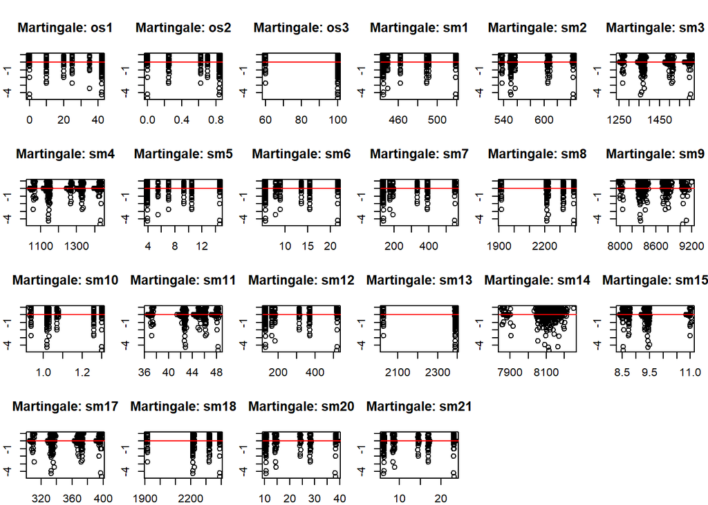

**Proportional Hazards Assumption**

The `cox.zph` function can be used to check the proportional hazards assumption. As mentioned, the function calculates p-values for each covariate. The global p-value will first be compared to $\alpha = 0.05$. If that p-value is $<\alpha$, then at least one covariate violates the PH assumption, and the model will need to be adapted.

The output below shows the p-values for the hypothesis test and Schoenfeld residuals. The global p-value is $> \alpha$ so none of the covariates violates the PH assumption on a global level. Examining each individual covariate through both p-values and the plot of the Schoenfeld residuals does show that os1, os3, sm13, and sm14 violate the PH assumption. However, since the global p-value does show that the model itself meets the PH assumption, the analysis will proceed with those covariates. If the global p-value had not met the assumption, further analysis of those four covariates would need to be completed in order to met the PH assumption.

```r
cph_ph <- cox.zph(cox1.1) %>%
  pluck("table") %>%
  as.data.frame() %>%
  tibble::rownames_to_column("variable") %>%
  as_tibble()
kable(cph_ph, format = "markdown")
```

| variable | chisq | df | p |
| --- | --- | --- | --- |
| os1 | 4.2930337 | 1 | 0.0382688 |
| os2 | 2.1883730 | 1 | 0.1390561 |
| os3 | 6.0092500 | 1 | 0.0142311 |
| sm1 | 3.0837610 | 1 | 0.0790775 |
| sm2 | 1.0929062 | 1 | 0.2958282 |
| sm3 | 0.2445716 | 1 | 0.6209236 |
| sm4 | 0.4027613 | 1 | 0.5256666 |
| sm5 | 3.6568634 | 1 | 0.0558387 |
| sm6 | 3.0658937 | 1 | 0.0799512 |
| sm7 | 2.2522133 | 1 | 0.1334234 |
| sm8 | 0.8645895 | 1 | 0.3524575 |
| sm9 | 0.0000044 | 1 | 0.9983242 |
| sm10 | 0.2065991 | 1 | 0.6494461 |
| sm11 | 0.1480541 | 1 | 0.7004019 |
| sm12 | 2.2424732 | 1 | 0.1342661 |
| sm13 | 6.0884122 | 1 | 0.0136071 |
| sm14 | 12.7697921 | 1 | 0.0003523 |
| sm15 | 1.2925760 | 1 | 0.2555738 |
| sm17 | 0.2784858 | 1 | 0.5976954 |
| sm18 | 0.8414520 | 1 | 0.3589818 |
| sm20 | 2.5560438 | 1 | 0.1098732 |
| sm21 | 2.5387409 | 1 | 0.1110833 |
| GLOBAL | 32.9551558 | 22 | 0.0625074 |

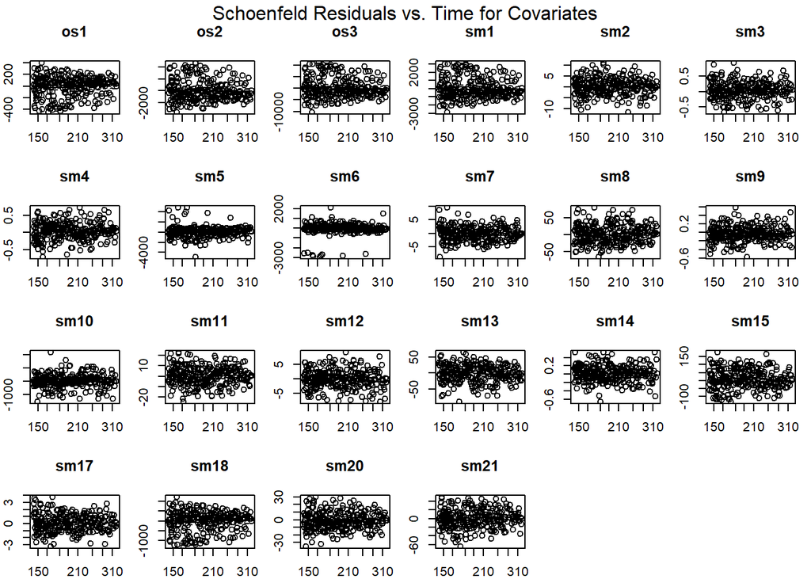

### Model Results

**Evaluation**

**Calculations**

The CPH model created produced coefficients for each covariate indicating the quantitative effect on the resulting hazard rate. The coefficients are shown below.

```r
coef <- data.frame(CoefficientValue = cox1.1$coefficients)
kable(coef, format = "markdown")
```

|  | CoefficientValue |
| --- | --- |
| os1 | -3.9742724 |
| os2 | 26.0627144 |
| os3 | 121.3783096 |
| sm1 | 30.4694993 |
| sm2 | 0.0605400 |
| sm3 | 0.0444578 |
| sm4 | 0.0431476 |
| sm5 | 48.6182429 |
| sm6 | -39.9302995 |
| sm7 | -0.0993847 |
| sm8 | 2.2569004 |
| sm9 | -0.0306124 |
| sm10 | 15.2195207 |
| sm11 | 0.4295235 |
| sm12 | 0.0129785 |
| sm13 | -1.3811545 |
| sm14 | 0.0150787 |
| sm15 | 8.7483795 |
| sm17 | 0.1061484 |
| sm18 | -14.8583117 |
| sm20 | -1.0226085 |
| sm21 | -0.3429034 |

The coefficients above can be used to calculate the hazard rate (Equation 2), the cumulative hazard value (Equation 5), and the survival probability (Equation 8). The hazard rate at time $t$ will be calculated for each engine at the engine’s max time value. The cumulative hazard value is the total hazard accumulated for the subject over time and is used to estimate the risk for the subject at a point in time. The engines that have higher hazard rates or higher cumulative hazard values are at a greater risk of experiencing failure. The below table provides the hazard rate and survival probability for the first 10 engines in the dataset.

```r
data_grouped_reduced <- data_grouped %>% select(id, time, os1, os2, os3, sm1, sm2, sm3, sm4, sm5, sm6, sm7, sm8, sm9, sm10, sm11, sm12, sm13, sm14, sm15, sm17, sm18, sm20, sm21, status)


data_grouped_reduced$HazardRate <- predict(cox1.1,
        newdata = data_grouped_reduced,
        type = "risk")

data_grouped_reduced$SurvivalProbability <- predict(cox1.1, type = "survival", newdata = data_grouped_reduced)

print_data <- data_grouped_reduced %>% select(id, time, status, HazardRate, SurvivalProbability)

kable(head(print_data, n = 10), format = "markdown")
```

| id | time | status | HazardRate | SurvivalProbability |
| --- | --- | --- | --- | --- |
| 1 | 149 | 1 | 7.657873 | 0.8617456 |
| 2 | 269 | 1 | 2.585519 | 0.1719981 |
| 3 | 206 | 1 | 3.085786 | 0.4688056 |
| 4 | 235 | 1 | 1.488771 | 0.5305390 |
| 5 | 154 | 1 | 1.492792 | 0.9575895 |
| 6 | 175 | 1 | 6.786967 | 0.5932495 |
| 7 | 174 | 1 | 1.584901 | 0.8871215 |
| 8 | 151 | 1 | 3.065598 | 0.9271080 |
| 9 | 199 | 1 | 5.816140 | 0.3373639 |
| 10 | 184 | 1 | 4.944125 | 0.5733033 |

The below graphs demonstrate the cumulative hazard over time and the survival curve from the prediction model.

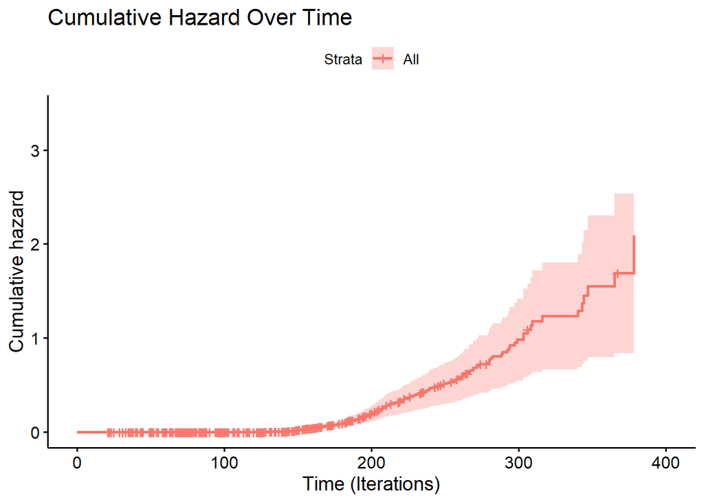

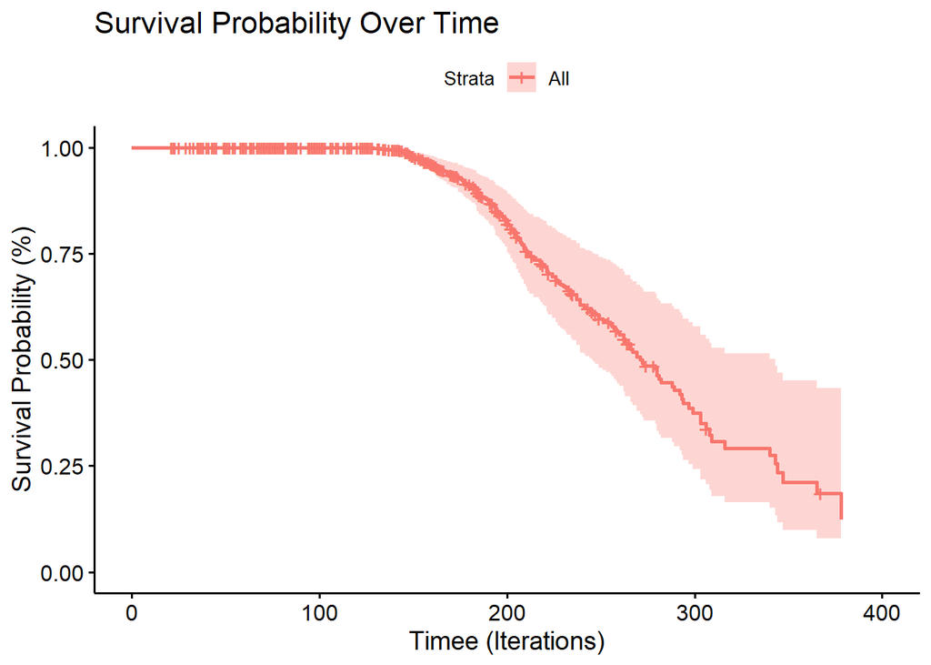

## Conclusion

The implications of an engine failure are severe, as failure can lead to injury or death and the loss of millions of dollars. As such, understanding when an engine will fail allows for maintenance to occur before negative impacts occur. While CPH does not allow for the prediction of specific failure times, it does allow for the creation of confidence intervals, which can be used to gain an understanding of when engines are most likely to fail. The table below displays the percent of survival at the lower end of the confidence interval to exercise caution.

```r
kable(survtimes, format = "markdown")
```

| Percent | Time |
| --- | --- |
| 100% Survival | 128 |
| 75% Survival, | 201 |
| 50% Survival | 245 |
| 25% Survival | 299 |
| 10% Survival | 347 |

The lower end of the confidence interval for survival probability is shown to hold stable at 100% until `t = 128`, with a gradual decrease afterwards. Half of the engines are expected to survive until `t = 245`, and 90% of the engines are expected to fail at `t = 347`. These results can be viewed in both the above survival graph and the cumulative hazard plot which shows a low hazard until `t = 128` with a gradual increase. The model’s final concordance index of .696 indicates that the calculated confidence interval is fairly accurate, but it is still subject to a substantial margin for error.

Based on these findings, the model can be applied by recommending that NASA not use engines after 128 iterations have passed. The engines should undergo routine maintenance beforehand and should be evaluated to ensure the probability of survival calculated by the model remains at 100%. All engines should be equipped with sensors for the covariates used, and readings should be applied to the model after each use of the engine. The engine should be removed from service if the resulting survival probability is less than 100%.

While the concordance index of .696 achieved in this analysis demonstrates the model is fairly accurate, there is still room for improvement. Survival models resulting in a concordance index of .9 or higher are highly accurate and would provide a tighter, more accurate confidence interval for the longevity of engines. After attempting transformations of the data and creating models with many different combinations of covariates, the final c-index that was calculated is the highest value achieved where the covariates were able to meet the proportional hazards model.

As discussed previously, a weakness of the Cox proportional hazards model is the necessity to meet the proportional hazards assumption. Given the difficulty of meeting the PH assumption, a different survival analysis would have better suited this dataset.

## References

Abeysekera, W. W. M., and M. R. Sooriyarachchi. 2009. “Use of Schoenfeld’s Global Test to Test the Proportional Hazards Assumption in the Ox Proportional Hazards Model: An Application to a Clinical Study.” https://www.researchgate.net/publication/238483310_Use_of_Schoenfeld's_global_test_to_test_the_proportional_hazards_assumption_in_the_Cox_proportional_hazards_model_An_application_to_a_clinical_study.

Amini, Zaki. 2015. “Log-Linearity for Cox’s Regression Model.” https://www.duo.uio.no/bitstream/handle/10852/45377/thesis_zaki.pdf?sequence=15&isAllowed=y.

Asghar, Naseem, Khalil Umair, and Iftikhar Uddin. 2024. “Mixture and Non-Mixture Cure Models for the Survival Analysis of SARS-CoV-2 Patients in Khyber Pakhtunkhwa, Pakistan.” *Pakistan Journal of Medical Sciences* 40 (8): 1841–46.

Bustan, M. Nadjib. 2018. “Cox Proportional Hazard Survival Analysis to Inpatient Breast Cancer Cases.”

Harrison, Ewen, and Riinu Pius. 2021. *R for Health Data Science*. 1st ed. Chapman & Hall.

Jiang, Nan, Wu Yongfa, and Chengjia Li. 2024. “Limitations of Using COX Proportional Hazards Model in Cardiovascular Research.” *Cardiovascular Diabetology*, no. 1: 1–2.

Klein, John P., and Melvin L. Moeschberger. 2005. *Survival Analysis: Techniques for Censored and Truncated Data*. 2nd ed. Springer.

Kuitunen, Ponkilainen, I. 2021. “Testing the Proportional Hazards Assumption in Cox Regression and Dealing with Possible Non-Proportionality in Total Joint Arthroplasty Research: Methodological Perspectives and Review.” https://link.springer.com/article/10.1186/s12891-021-04379-2.

Lee, Ming-Chang. 2014. “Business Bankruptcy Prediction Based on Survival Analysis Approach.” *International Journal of Computer Science & Information Technology* 6 (2): 103–19.

Lee, Seung Won. 2023. “Kaplan-Meier and Cox Proportional Hazards Regression in Survival Analysis: Statistical Standard and Guideline of Life Cycle Committee.” https://www.elifecycle.org/.

Nahhas, Ramzi W. 2025. *Introduction to Regression Methods for Public Health Using r*. 1st ed. Chapman & Hall.

R Core Team. 2019. *R: A Language and Environment for Statistical Computing*. Vienna, Austria: R Foundation for Statistical Computing. https://www.R-project.org.

Saxena, Abhinav, Kai Goebel, Don Simon, and Neil Eklund. 2008. “Damage Propagation Modeling for Aircraft Engine Run-to-Failure Simulation,” 1–9. https://doi.org/10.1109/PHM.2008.4711414.

Therneau, Terry M., and David A. Watson. 2017. “The Concordance Statistic and the Cox Model.” https://www.mayo.edu/research/documents/bsi-techreport-85/doc-20433003.

Tyler Smith, MPH;, MS; Besa Smith, and MPH Margaret AK Ryan MD. 2003. “Survival Analysis Using Cox Proportional Hazards Modeling for Single and Multiple Event Time Data.” https://www.ms.uky.edu/~mai/sta635/sugi254-28.pdf.

Wang, Weiwei, Xiaotian Chang, and Feifei Lin. 2025. “Adding Salt to Foods and Risk of Incident Depression and Anxiety.” *BMC Medicine*, no. 1: 1–10.

Zapletal, David. 2021. “Application of the Cox Proportional Hazards Model and Competing Risks Models to Critical Illness Insurance Data.” *Statistical Analysis & Data Ming* 14 (4): 342–51.

Zhang, Yue, Yangyang Cheng, and Rodrigo M Carrillo-Larco. 2025. “Postpartum Depression in Relation to Chronic Diseases and Multimorbidity in Women’s Mid-Late Life: A Prospective Cohort Study of UK Biobank.” *BMC Medicine* 23 (1): 1–13.

Ziadi, C, J P Sánchez, M Sánchez, R Morales, and A Molina. 2023. “Survival Analysis of Productive Life in Florida Dairy Goats Using a Cox Proportional Hazards Model.” *Journal of Animal Breeding & Genetics* 140 (4): 431–39.